# Spatial Visualization

Sorongon_Sierra

2025-08-21

# Introduction

Spatial visualization is a powerful tool that transforms data into a geographic context, helping us see patterns, trends, and hotspots across space. By mapping variables such as disease incidence, environmental measurements, or resource distribution, we can compare areas, identify clusters, and communicate insights more effectively. These visualizations not only enhance understanding of complex datasets but also provide a foundation for evidence-based decision making and targeted interventions in fields ranging from public health to urban planning and environmental management.

# Step 1: Base Map of the Philippines

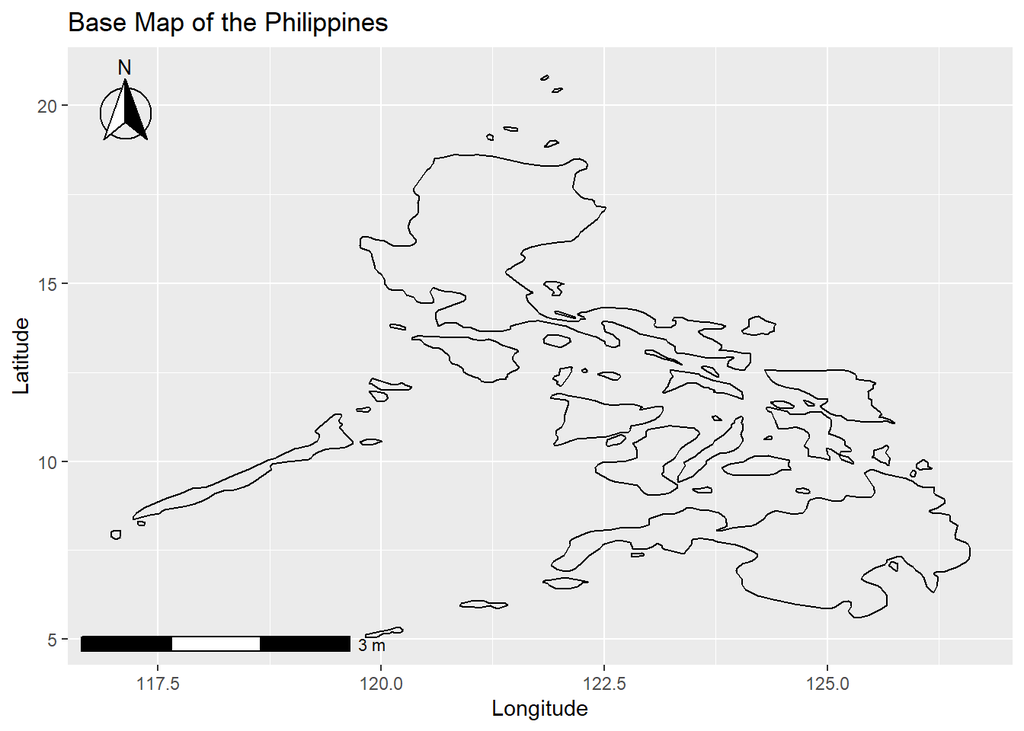

```r
# Get Philippines map
ph_map <- map_data("world", region = "Philippines")

# Plot base map only
ggplot() +
  geom_polygon(data = ph_map,
               aes(x = long, y = lat, group = group),
               color = "black", size = 0.5, fill = NA) +
  labs(title = "Base Map of the Philippines",
       x = "Longitude", y = "Latitude") +
  annotation_scale(location = "bl", width_hint = 0.3) +
  annotation_north_arrow(location = "tl", which_north = "true",
                         style = north_arrow_fancy_orienteering())
```

📌 **Why important?** This base map provides geographic context by showing the outline of the Philippines. It serves as a neutral background on which additional spatial data (such as air pollution levels, monitoring sites, or population density) can later be overlaid.

# Step 2: Adding Administrative Boundaries and Cities

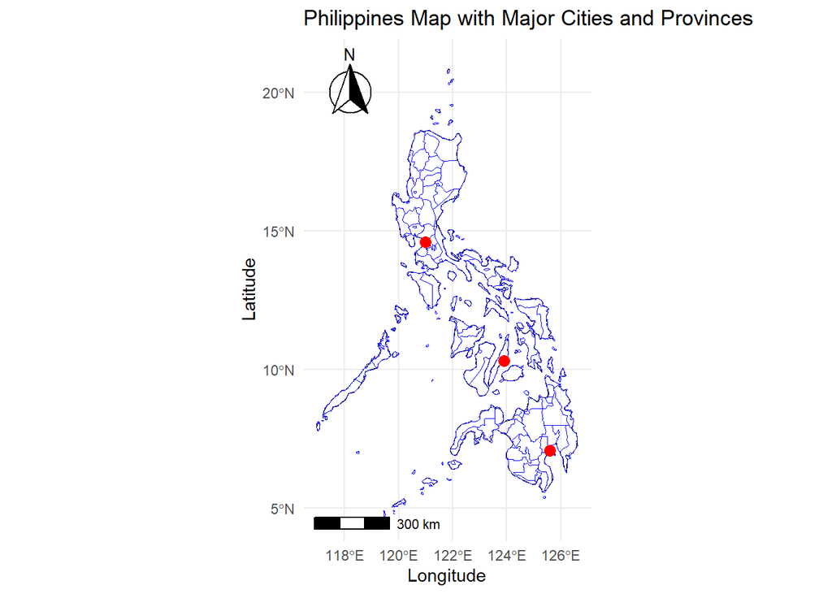

```r
# Get Philippines boundary
ph_country <- ne_countries(scale = "medium", country = "Philippines", returnclass = "sf")

# Get provinces
ph_provinces <- ne_states(country = "Philippines", returnclass = "sf")

# Example cities (replace with actual dengue case locations or hospitals)
cities <- data.frame(
  city = c("Manila", "Cebu", "Davao"),
  lon = c(120.98, 123.89, 125.6),
  lat = c(14.6, 10.32, 7.07)
)

# Plot
ggplot() +
  geom_sf(data = ph_country, fill = NA, color = "black", size = 0.8) +
  geom_sf(data = ph_provinces, fill = NA, color = "blue", size = 0.5) +
  geom_point(data = cities, aes(x = lon, y = lat), color = "red", size = 3) +
  labs(title = "Philippines Map with Major Cities and Provinces",
       x = "Longitude", y = "Latitude") +
  annotation_scale(location = "bl", width_hint = 0.3) +
  annotation_north_arrow(location = "tl", which_north = "true",
                         style = north_arrow_fancy_orienteering()) +
  theme_minimal()
```

📌 **Why important?** Administrative boundaries (provinces, regions, districts, etc.) provide a framework to compare data across geographic areas. This allows us to identify patterns, trends, or hotspots in any spatial dataset—for example, determining which areas have the highest disease incidence, resource needs, or environmental risks.

# Step 3: Municipal-Level Choropleth for Iloilo

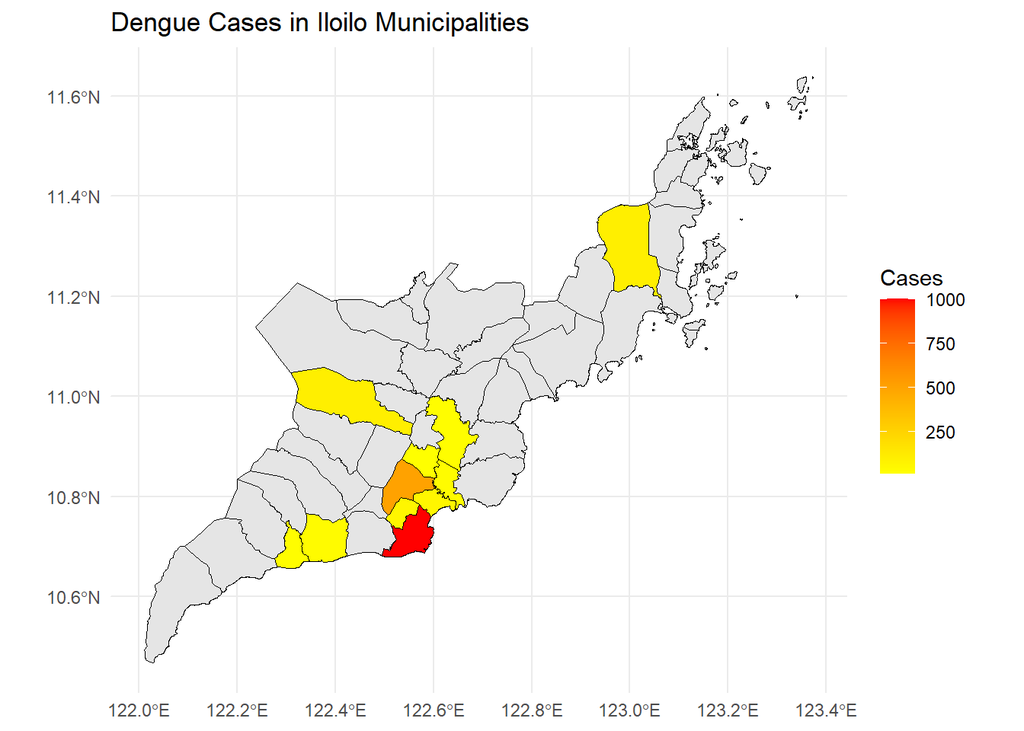

```r
# Download municipalities (admin level 2)
ph_muni <- gadm(country = "PHL", level = 2, path = tempdir())
ph_muni_sf <- st_as_sf(ph_muni)

# Filter for Iloilo province
iloilo_muni <- ph_muni_sf %>%
  filter(NAME_1 == "Iloilo")

# Example any count data
cases_data <- data.frame(
  NAME_2 = c("New Lucena", "Zarraga", "Pototan", "Janiuay", "Santa Barbara",
             "Pavia", "Iloilo City", "Leganes", "Guimbal", "Tigbauan", "Sara"),
  cases = c(10, 29, 21, 100, 500, 59, 1000, 60, 21, 30, 100)
)

# Join with spatial polygons
iloilo_map <- iloilo_muni %>%
  left_join(cases_data, by = "NAME_2")

# Plot choropleth
ggplot(iloilo_map) +
  geom_sf(aes(fill = cases), color = "black", size = 0.2) +
  scale_fill_gradient(low = "yellow", high = "red", na.value = "grey90") +
  labs(title = "Dengue Cases in Iloilo Municipalities",
       fill = "Cases") +
  theme_minimal()
```

📌 **Why important?** **Choropleth maps allow us to visualize the intensity of a variable across geographic areas.**

- Darker colors indicate higher values.
- Lighter colors indicate lower values.

This is important for **identifying patterns and targeting actions**, whether for public health, resource allocation, environmental management, or other spatially distributed phenomena.

# Conclusion

Through these steps, we have:

1. Built a **base geographic map** of the Philippines.
2. Added **administrative boundaries and major cities**.
3. Created a **choropleth map of Iloilo dengue cases**.

This pipeline demonstrates how spatial visualization turns **tabular case data** into **actionable geographic insights**, which can guide both **research** and **public health planning**.